# StatR 502: Lab 0

January 5, 2016

## Welcome to StatR 502!

Tonight's Menu:

- Course logistics *briefly* (more on Thursday)
- Easy, reproducible, organized documents with `knitr`
- Intro to `ggplot2`

## Logistics

- Me
- Website - use the forums!
- Content
- Book

## knitr

## What is `knitr`?

- Tool for producing reports / presentations - or just narrating an analysis
- Keeps R code and write-up in one document, *together*
- knit documents should be **self-contained**

## Markdown is easy!

Markdown was designed with the goals of being easy to read and easy to write, with special emphasis on readability of the code.

You're probably already familiar with some markdown conventions even if you don't know it!

The RStudio website has very nice introductions to [Markdown](http://rmarkdown.rstudio.com/authoring_basics.html) and [rmarkdown](http://rmarkdown.rstudio.com/)

## Embedding code

- Code chunks
- Inline code

## Possibe conversions

`knitr` is extremely flexible.

- **input** Markdown is the simplest input language, but you can also use \(\LaTeX\) (typically with the file extension `.Rnw`), HTML, AsciiDoc, etc. as the input language.
- **code** With configured installations, you can evaluate code for languages other than R. [There are examples](http://yihui.name/knitr/demo/engines/) for Python, Ruby, Haskell, and many others (though support for R is strongest).
- **output** `knitr` itself implements the narrowly-scoped task of evaluating R code and inserting appropriately formatted output into your document. Conversion is then handled by Pandoc (e.g. `knitr` turns `.Rmd` to `.md`, or `.Rnw` to `.tex`; Pandoc takes the `.md` or `.tex` and turns it into HTML, PDF, Word, etc. Pandoc relies on \(\LaTeX\) for conversions to PDF.)

## Chunk options

- Display & code: `echo`, `eval`, `include`, `results`
- Figures: `fig.keep`, `fig.width`, `fig.height`, `out.width`, `out.height`, `dpi`
- Other output: `message`, `warning`, `error`

Not all chunk options work for all output formats. The best documentation is on [Yihui's website](http://yihui.name/knitr/options/#chunk_options).

## Setting options

There are default options for code chunks (`echo = TRUE`, `eval = TRUE`, …). If you want to set different default options for your document, you can use `opt_chunk$set()`. To programmatically access a current option, use `opt_chunk$get()`. For example

```r
opts_chunk$set(eval = FALSE)
opts_chunk$get("fig.width")
```

The above chunk would make subsequent chunks unevaluated by default. Often the first chunk in a document will set some options (e.g., figure widths and heights) and load necessary packages. It can be hidden with its own option set to `include = FALSE`.

## Common "gotchas"

- If a figure looks poor, experiment with both `fig.height/width` and `dpi` (HTML/Word) or `out.height/width` (PDF).
- The code in the document should be able to stand alone - load all packages you need.
  - The RStudio shortcut compiles your document in a separate R session, so it **must** be self-contained.
  - If you use `knitr` functions (like `opts_chunk$set()`) *inside* code chunks, you need to load `knitr`.
- Make sure you save your changes before knitting! (This is taken care of for you if you use the shortcut in RStudio.)
- Don't use the `.Rpres` "R presentation" format; it is mostly deprecated - for presentations use HTML formats like `io_slides` or `Slidy` (accessible via Pandoc), `slidify` (which has its own R package), or PDF via Beamer.

## ggplot2

## Advantages and Disadvantages

`ggplot2` is the cure to the headaches you get when you try to make beautiful, effective plots using R's other graphics packages (base graphics and lattice).

The "gg" stands for "Grammar of Graphics", which is a creation of Leland Wilkinson (he has a book on the topic of the same name). The `ggplot2` package is an R implementation by Hadley Wickham.

- Advantages: consistent and accessible syntax, and lattice-like ability to create "small multiples" of graphs (called *facets*), customizable theming system, wide array of easily modified options.
- Disadvantages: **requires** data frames, in relatively specific formats. Some adjustments are near impossible. Modifications outside of the (wide array of) standard options can be very difficult.

With great ease of use comes loss in flexibility.

## Philosophy

R "2.0", with Hadley Wickham as the figurehead:

- `ggplot2` for graphs
- `dplyr` and `tidyr` for data manipulation
- `lubridate` for handling dates and times
- `stringr` for string manipulation
- `knitr` for publishing
- And more: `httr`, `devtools`, `testthat`, `roxygen2`, `readr`, `ggvis`, the list goes on…

Consistent syntax and improved readability for faster work and fewer bugs.

## Grammar of Graphics

Dimensions of data correspond to dimensions in the graph.

The most commonly used graphical dimensions are x-position, y-position, and color. What other graphical dimensions can you think of?

In `ggplot`, the correspondences between data and graphical dimensions are called *aesthetic mappings*. They are set inside of the `aes()` argument.

## Building a ggplot

A ggplot always starts by setting up your data and the aesthetic mappings:

```r
ggplot(mtcars, aes(x = wt, y = mpg))
```

Inside `aes()` you put all the relations between visualization and your data. Use "unquoted" column names.

(In general, whenever a function has a `data` argument, you shouldn't need to re-specify the data frame name to refer to columns.)

## Building a ggplot

And then literally adding geometries ("geoms") - data visualization elements.

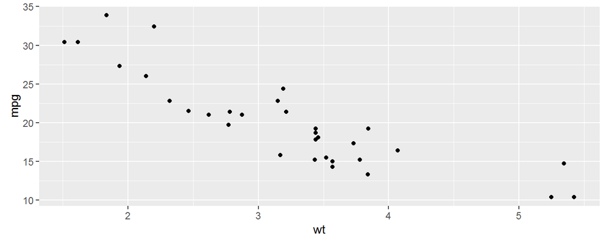

```r
ggplot(mtcars, aes(x = wt, y = mpg)) +
  geom_point()
```

## Building a ggplot

You can specify more `aes()` details inside a `geom()` (or up front in the original `ggplot()`), but if you are assigning **constants** (unconnected to data), keep it outside of `aes()`.

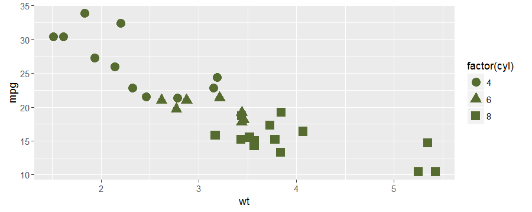

```r
ggplot(mtcars, aes(x = wt, y = mpg)) +
  geom_point(aes(shape = factor(cyl)), color = "darkolivegreen", size = 4)
```

Data inside `aes()`, constants outside `aes()`. Notice that we *don't* need to specify the data that the columns come from, no need for `shape = factor(mtcars$cyl)`. Subsequent functions will "know" to look inside the already-specified data frame for anything inside `aes()`.

## Building a ggplot

There's lots of geoms, some of the standards are `geom_point`, `geom_line`, `geom_bar`, `geom_boxplot`. You can see all of them with some pretty good examples at http://docs.ggplot2.org/current/. When looking at documentation for a geom, the most important info is the aesthetics.

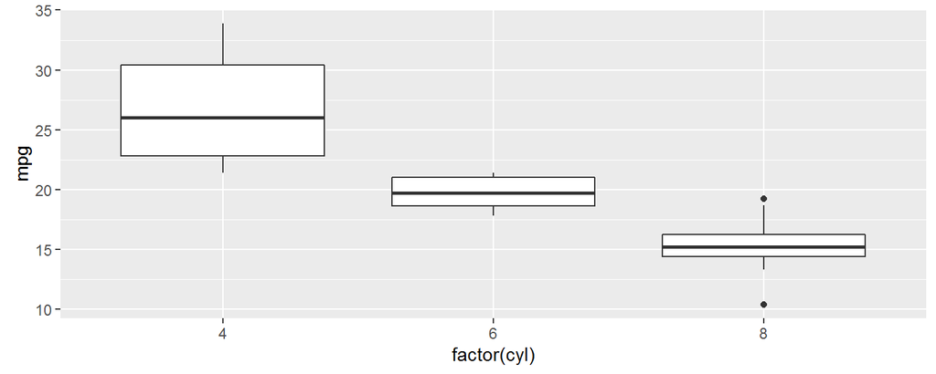

```r
ggplot(mtcars, aes(x = factor(cyl), y = mpg)) +
  geom_boxplot()
```

## A `ggplot` is an object

`ggplots` are objects, and can be assigned to variables, and we can use more aesthetics than just `x` and `y`. But just like other variables in R, they don't print on assignment.

Coming from `base` graphics, this might seem strange and uncomfortable.

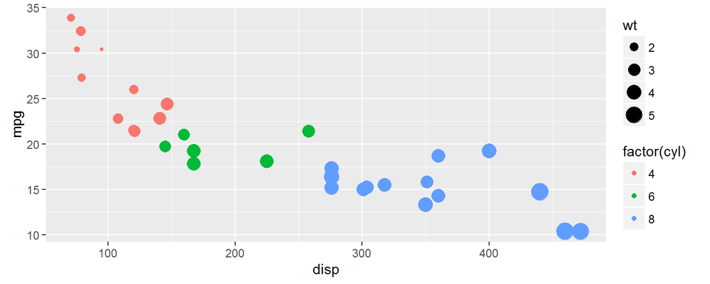

```r
mt <- ggplot(mtcars, aes(x = disp, y = mpg, size = wt,
                         color = factor(cyl))) +
  geom_point()
mt
```

## A `ggplot` is an object

It can be modified.

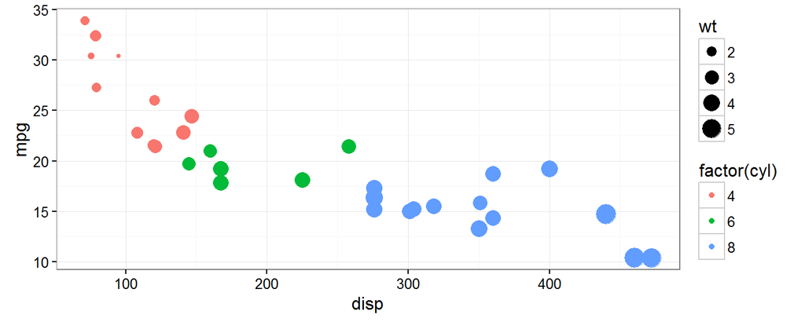

```r
mt + theme_bw()
```

This is very different from base, and can save a lot of copy/pasting to make variations of the same graph.